# totaldeaths.net slides

## in case you've heard that covid deaths are inflated, let's look at deaths from all causes...

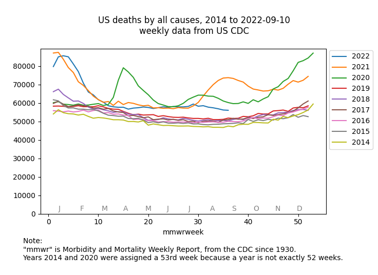

Many more people died (of all causes) in 2020 and 2021 than in previous years. But how many deaths might be due to covid, rather than say suicide or overdose? Next we look at deaths from all natural causes.

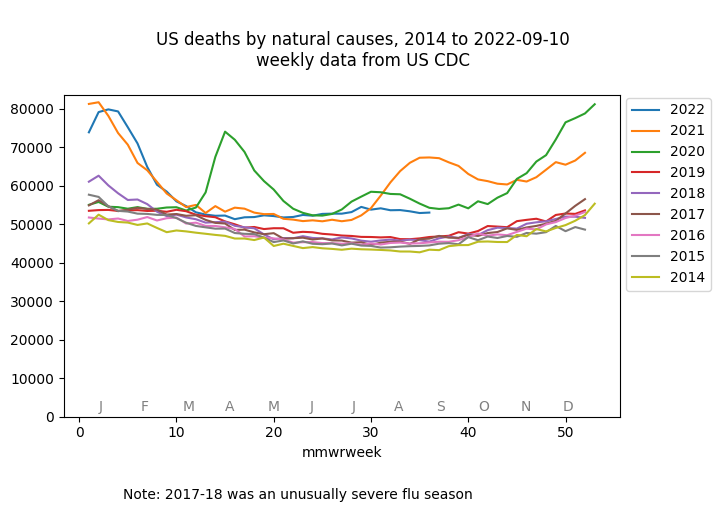

We see much higher weekly deaths from natural causes since week 12 of 2020. How many more people are dying than we would expect? For "excess deaths" we simply use 2019 as our baseline and subtract the deaths in 2019 from those in 2020.

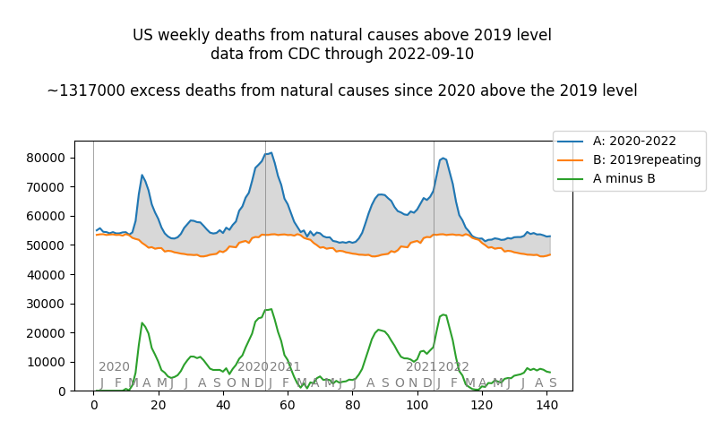

How many of these excess deaths were officially attributed to covid?

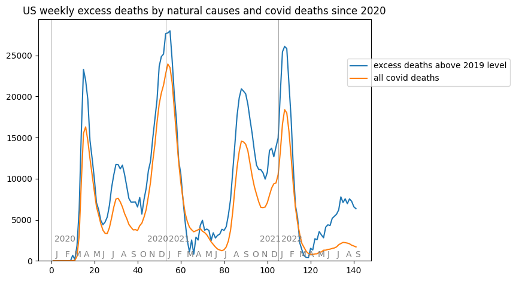

Excess deaths are greater than covid deaths except around March 2021 and March 2022. The two curves correlate fairly well.

As a sanity check, let's sum all the individual natural causes of death and compare it with the total that we've been using:

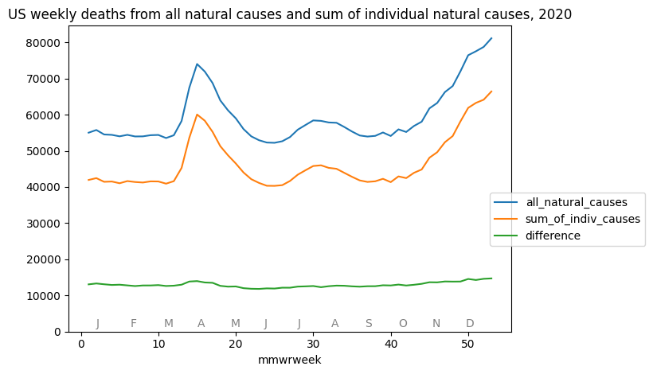

So the causes of death included in the MMWR are just the major ones--they add up to about 75% of the total deaths from natural causes. However, the difference is fairly constant, so we can see most of the interesting variation in the individual causes of death in the next slide...

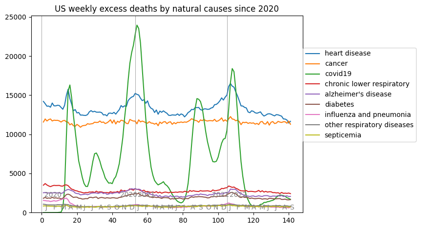

Presumably there is not usually a springtime peak in heart attacks, but let's check in the next slide...

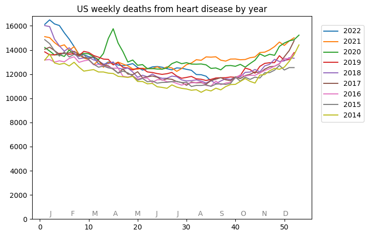

Indeed, the springtime heart attack peak is unique to 2020. This peak, and the subsequent excess heart deaths in weeks 25-35, could reflect deaths that should have been attributed to covid, or deaths of people who pre-pandemic would have gone to the hospital and survived but avoided the hospital due to fear of covid. It will take time for the CDC to tease apart the [direct vs indirect deaths due to covid](https://www.cdc.gov/mmwr/volumes/69/wr/mm6942e2.htm?s_cid=mm6942e2_w).

# next steps

- add more precise dates to single-year plots.
- explore excess deaths by state/region.
- derive undercount_from_latest (a result used above), and maybe correct for it.
- want to help? have a comment? email me at john@saponara.us or pursue any next step or code "todo" and please let me know.

# sources

- visit [here](https://github.com/jsaponara/pandemic_death_data/blob/main/deaths-us-natural_cause.ipynb) for complete details, including data sources and the code that generated these slides.